# Linear Regression Models

Author

Alexa Marin

# Intro to Machine Learning; Linear Regression Models

```python
import pandas as pd
import numpy as np
import matplotlib.pyplot as plt
from sklearn.linear_model import LinearRegression
from sklearn.metrics import r2_score, mean_squared_error
from sklearn.model_selection import cross_val_score, KFold
```

## Music Challenge

Which popular songs from the past will be recognized by future generations, and which will fade into obscurity? The website [The Pudding](https://pudding.cool/) conducts the [Music Challenge](https://pudding.cool/2020/04/music-challenge/) where they ask thousands of people whether they recognize hit songs from the past. We’ll look at some of the data related to the article [“Defining the 90s Music Canon”](https://pudding.cool/2020/07/song-decay/).

The data set at https://raw.githubusercontent.com/the-pudding/song-decay-clean/refs/heads/master/src/assets/data/lollipop_chart_data_july_13.csv contains 344 songs released in the 1990s. For each song, the proportion of survey respondents who recognized the song is recorded, for both Millennial respondents and Gen Z respondents. Our goal will be to use linear regression to **predict the Gen Z recognition**.

We will try several different linear regression models. Save each of your models with a different name because you will compare them at the end.

0. Read in the data and describe the Gen Z recognition variable.

```python
music = pd.read_csv("https://raw.githubusercontent.com/the-pudding/song-decay-clean/refs/heads/master/src/assets/data/lollipop_chart_data_july_13.csv")
music

music["mean_gen_z_recognition"].describe()
```

```
count    344.000000
mean       0.235506
std        0.210541
min        0.019483
25%        0.095589
50%        0.155398
75%        0.303051
max        0.963497
Name: mean_gen_z_recognition, dtype: float64
```

1. Use scikit-learn to fit a linear regression model for predicting Gen Z recognition from Millennial recognition.

```python
X_music = music[["mean_millennial_recognition"]]
y_music = music["mean_gen_z_recognition"]

linear_model = LinearRegression()
linear_model.fit(X_music, y_music)

print("slope:", linear_model.coef_[0])
print("intercept:", linear_model.intercept_)
print("R-squared:", linear_model.score(X_music, y_music))
```

```
slope: 0.7067311793153609
intercept: -0.04814972198183046
R-squared: 0.7969941647566873
```

2. Make a scatterplot of Gen Z recognition versus Millennial recognition, and overlay a graph of the fitted model from the previous part.

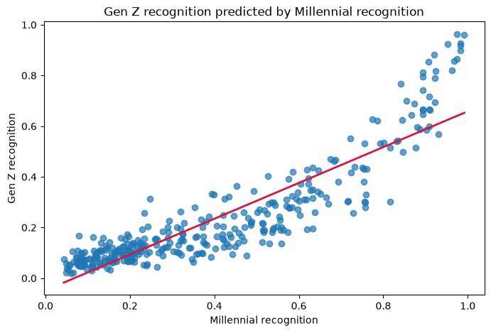

```python
x_grid = np.linspace(X_music.min().iloc[0], X_music.max().iloc[0], 200).reshape(-1, 1)

plt.figure(figsize=(8, 5))
plt.scatter(X_music, y_music, alpha=0.7)
plt.plot(x_grid, linear_model.predict(x_grid), color="crimson", linewidth=2)
plt.xlabel("Millennial recognition")
plt.ylabel("Gen Z recognition")
plt.title("Gen Z recognition predicted by Millennial recognition")
plt.show()
```

The straight line misses the shape of the data. The points curve upward: Gen Z recognition stays low until Millennial recognition is fairly high, then rises steeply. So the line **overpredicts** in the middle and **underpredicts** the best-known songs. Its intercept is negative, and it predicts a *negative* recognition, which is impossible, for the 11 songs with Millennial recognition below about 0.07.

3. Explain why you might want to consider taking a log of Gen Z recognition. Then use scikit-learn to fit a linear regression model for predicting log of Gen Z recognition from Millennial recognition.

```python
# Gen Z recognition is a proportion between 0 and 1 and is right-skewed.
# Taking a log can make the relationship less curved and reduce the influence of very large values.
log_model = LinearRegression()
log_model.fit(X_music, np.log(y_music))

print("slope:", log_model.coef_[0])
print("intercept:", log_model.intercept_)
print("R-squared for log(Gen Z recognition):", log_model.score(X_music, np.log(y_music)))
```

```
slope: 2.7991680362225217
intercept: -2.9082912239452847
R-squared for log(Gen Z recognition): 0.8230294902084205
```

4. Make a scatterplot of Gen Z recognition versus Millennial recognition, and overlay a graph of the fitted model from the previous part.

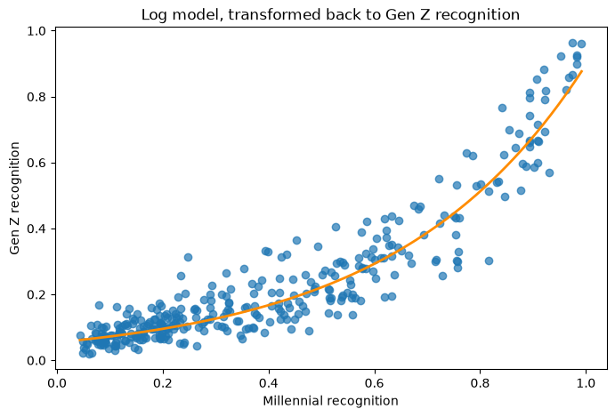

```python
plt.figure(figsize=(8, 5))
plt.scatter(X_music, y_music, alpha=0.7)
plt.plot(x_grid, np.exp(log_model.predict(x_grid)), color="darkorange", linewidth=2)
plt.xlabel("Millennial recognition")
plt.ylabel("Gen Z recognition")
plt.title("Log model, transformed back to Gen Z recognition")
plt.show()
```

5. Now we’ll try a polynomial model for predicting Gen Z recognition from Millennial recognition. Use scikit-learn to fit a model with two features: Millennial recognition and its square.

```python
X_square = pd.DataFrame({
    "millennial_recognition": music["mean_millennial_recognition"],
    "millennial_recognition_squared": music["mean_millennial_recognition"] ** 2,
})

square_model = LinearRegression()
square_model.fit(X_square, y_music)
```

```
LinearRegression()
```

```python
square_model.coef_, square_model.intercept_
```

```
(array([-0.27263527,  1.02072241]), np.float64(0.10851294576257658))
```

6. Make a scatterplot of Gen Z recognition versus Millennial recognition, and overlay a graph of the fitted model.

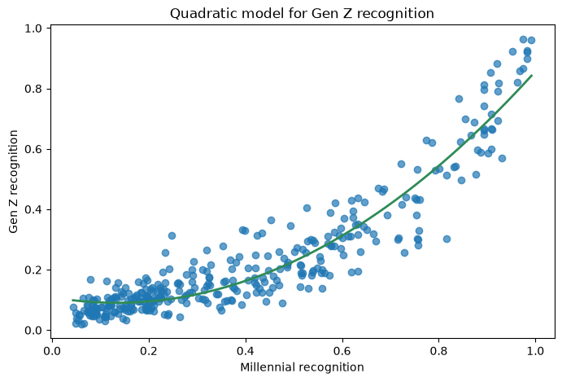

```python
x_square_grid = pd.DataFrame({
    "millennial_recognition": x_grid.ravel(),
    "millennial_recognition_squared": x_grid.ravel() ** 2,
})

plt.figure(figsize=(8, 5))
plt.scatter(X_music, y_music, alpha=0.7)
plt.plot(
    x_grid,
    square_model.predict(x_square_grid),
    color="seagreen",
    linewidth=2
)

plt.xlabel("Millennial recognition")
plt.ylabel("Gen Z recognition")
plt.title("Quadratic model for Gen Z recognition")
plt.show()
```

7. Choose one of your favorite songs that is in the data set. Use each model to predict the Gen Z recognition for the song. Which model gives the best prediction?

```python
favorite = music[music["artist_song"].str.contains("No Scrubs", case=False, na=False)].copy()

favorite_x = favorite[["mean_millennial_recognition"]]

favorite_x_square = pd.DataFrame({
    "millennial_recognition": favorite_x["mean_millennial_recognition"],
    "millennial_recognition_squared": favorite_x["mean_millennial_recognition"] ** 2,
})

favorite_results = pd.DataFrame({
    "actual Gen Z recognition": favorite["mean_gen_z_recognition"].values,
    "linear prediction": linear_model.predict(favorite_x),
    "log-model prediction": np.exp(log_model.predict(favorite_x)),
    "quadratic prediction": square_model.predict(favorite_x_square),
}, index=favorite["artist_song"])

for model in ["linear prediction", "log-model prediction", "quadratic prediction"]:
    favorite_results[f"{model} error"] = (
        favorite_results[model] - favorite_results["actual Gen Z recognition"]
    ).abs()

favorite_results
```

| artist_song | actual Gen Z recognition | linear prediction | log-model prediction | quadratic prediction | linear prediction error | log-model prediction error | quadratic prediction error |
| --- | --- | --- | --- | --- | --- | --- | --- |
| TLC\|\|\|No Scrubs | 0.667104 | 0.582987 | 0.664624 | 0.67908 | 0.084118 | 0.00248 | 0.011975 |

**My song** is “No Scrubs” by TLC. The log model gave the best prediction because it predicted a Gen Z recognition of 0.6646, which was only 0.0025 away from the actual value. The quadratic model was also close, but the linear model had the largest error and underpredicted this popular song.

8. The song “Smells Like Teen Spirit” by Nirvana is inexplicably not included in the data set. Suppose the Millenial recognition of this song is 0.7. Use each model to predict the Gen Z recognition for this song. Which model gives the best prediction?

```python
nirvana_x = pd.DataFrame({"mean_millennial_recognition": [0.7]})
nirvana_x_square = pd.DataFrame({
    "millennial_recognition": [0.7],
    "millennial_recognition_squared": [0.7 ** 2],
})

nirvana_predictions = pd.Series({
    "linear model": linear_model.predict(nirvana_x)[0],
    "log model": np.exp(log_model.predict(nirvana_x))[0],
    "quadratic model": square_model.predict(nirvana_x_square)[0],
}, name="predicted Gen Z recognition")
nirvana_predictions
```

```
linear model       0.446562
log model          0.387177
quadratic model    0.417822
Name: predicted Gen Z recognition, dtype: float64
```

For “Smells Like Teen Spirit,” the linear model predicts 0.447, the log model predicts 0.387, and the quadratic model predicts 0.418. Since the song is not in the data, there is no actual Gen Z recognition value, so I cannot know for sure which model is best. I would choose the log model because similar songs with Millennial recognition close to 0.7 had an average Gen Z recognition of about 0.388, which is almost exactly the log model’s prediction.

## Categorical Predictors (FEV data)

Do non-smokers have better lungs than smokers? One measure of lung function is forced expiratory volume (FEV), the amount of air (in liters) an individual can exhale in the first second of forceful breath. Larger values of FEV are indicative of better functioning lungs. In a study, FEV was measured for a group of 654 subjects, along with whether or not they smoked and other variables.

```python
df_fev = pd.read_csv("https://raw.githubusercontent.com/kevindavisross/data301/refs/heads/main/data/FEV.csv")

df_fev
```

|  | ID | Smoking status | FEV | Height | Age (months) |
| --- | --- | --- | --- | --- | --- |
| 0 | 201 | non-smoker | 2.884 | 69.0 | 132 |
| 1 | 202 | non-smoker | 2.328 | 64.0 | 120 |
| 2 | 301 | non-smoker | 1.708 | 57.0 | 108 |
| 3 | 341 | non-smoker | 3.381 | 63.0 | 172 |
| 4 | 351 | non-smoker | 2.170 | 58.0 | 130 |
| ... | ... | ... | ... | ... | ... |
| 649 | 83841 | non-smoker | 2.115 | 50.0 | 58 |
| 650 | 83901 | non-smoker | 2.328 | 60.0 | 98 |
| 651 | 83951 | smoker | 3.069 | 65.0 | 130 |
| 652 | 83952 | non-smoker | 1.495 | 57.0 | 85 |
| 653 | 90001 | non-smoker | 2.785 | 69.0 | 131 |

654 rows × 5 columns

1. First fit a regression model with a single predictor: Smoking status. Since this variable is categorical you need to “dummify” it before fitting the model.

```python
smoke_dummy = pd.get_dummies(df_fev["Smoking status"], drop_first=True, dtype=int)
smoke_model = LinearRegression()
smoke_model.fit(smoke_dummy, df_fev["FEV"])

print("dummy-variable column:", smoke_dummy.columns.tolist())
print("coefficient:", smoke_model.coef_[0])
print("intercept:", smoke_model.intercept_)
```

```
dummy-variable column: ['smoker']
coefficient: 0.7107189238605204
intercept: 2.5661426146010187
```

2. What are the predictions from this model? How could we have known that those would be the predictions?

```python
group_means = df_fev.groupby("Smoking status")["FEV"].mean()
predictions_by_group = pd.DataFrame({
    "Smoking status": ["non-smoker", "smoker"],
    "predicted FEV": smoke_model.predict(pd.DataFrame({"smoker": [0, 1]})),
})

display(group_means)
display(predictions_by_group)
```

```
Smoking status
non-smoker    2.566143
smoker        3.276862
Name: FEV, dtype: float64
```

|  | Smoking status | predicted FEV |
| --- | --- | --- |
| 0 | non-smoker | 2.566143 |
| 1 | smoker | 3.276862 |

The model predicts 2.57 L for every non-smoker and 3.27 L for every smoker. These are just the average FEV values for each group. Since smoking status is the only predictor, the model gives one average prediction for non-smokers and one for smokers.

3. Look at the results for the previous parts. What do you notice? Is this what you expected? Remember: larger FEV means better lungs - who tends to have larger FEV, smokers or non-smokers?

Smokers have a higher average FEV than non-smokers: 3.28 L compared with 2.57 L. This was not what I expected because smoking is harmful to the lungs. Smoking status alone does not explain why this happened, so other factors, like age, may be affecting the results.

4. Suggest some explanations for why smokers tend to have *higher* FEV than non-smokers?

The smokers are probably older and taller than the non-smokers, which means they naturally have larger lungs and higher FEV. Smoking is likely not improving their lungs the simple model is missing important factors like age and body size. There are also fewer smokers in the data, and they may have only been smoking for a short time.

5. Fit a linear regression model with two predictors: smoking status and Age (and no interaction).

```python
print("Intercept:", round(fev_age_model.intercept_, 4))
print("Smoking status (smoker):", round(fev_age_model.coef_[0], 4))
print("Age (months):", round(fev_age_model.coef_[1], 4))
print("R-squared:", round(fev_age_model.score(X_fev_age, df_fev["FEV"]), 4))

print("\nNon-smoker line: FEV =",
      round(fev_age_model.intercept_, 3),
      "+",
      round(fev_age_model.coef_[1], 4),
      "× age in months")

print("Smoker line: FEV =",
      round(fev_age_model.intercept_ + fev_age_model.coef_[0], 3),
      "+",
      round(fev_age_model.coef_[1], 4),
      "× age in months")
```

[output not shown]

```
Intercept: 0.3681
Smoking status (smoker): -0.2172
Age (months): 0.0192
R-squared: 0.5759

Non-smoker line: FEV = 0.368 + 0.0192 × age in months
Smoker line: FEV = 0.151 + 0.0192 × age in months
```

6. Make a scatterplot of FEV versus Age, colored by smoking status, and overlay a graph of the fitted model.

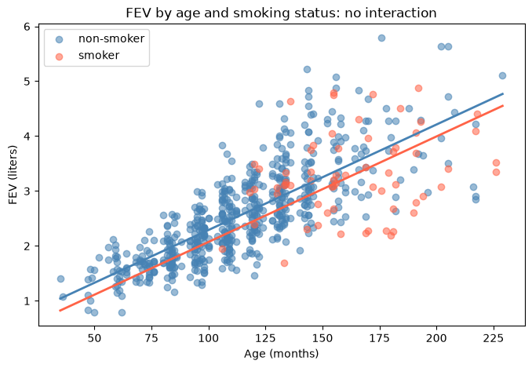

```python
plt.figure(figsize=(8, 5))
colors = {"non-smoker": "steelblue", "smoker": "tomato"}
age_grid = np.linspace(df_fev["Age (months)"].min(), df_fev["Age (months)"].max(), 200)

for status in ["non-smoker", "smoker"]:
    rows = df_fev[df_fev["Smoking status"] == status]
    plt.scatter(rows["Age (months)"], rows["FEV"], alpha=0.55, color=colors[status], label=status)
    line_data = pd.DataFrame({"smoker": [int(status == "smoker")] * len(age_grid), "Age (months)": age_grid})
    plt.plot(age_grid, fev_age_model.predict(line_data), color=colors[status], linewidth=2)

plt.xlabel("Age (months)")
plt.ylabel("FEV (liters)")
plt.title("FEV by age and smoking status: no interaction")
plt.legend()
plt.show()
```

7. Fit a linear regression model with predictors smoking status, Age, and their interaction.

```python
df_fev["Age (years)"] = df_fev["Age (months)"] / 12

X_int = pd.get_dummies(
    df_fev[["Smoking status"]],
    drop_first=True,
    dtype=int
)

X_int["Age (years)"] = df_fev["Age (years)"]
X_int["smoker_x_age"] = (
    X_int["Smoking status_smoker"] * X_int["Age (years)"]
)

y_fev = df_fev["FEV"]

interaction_model = LinearRegression()
interaction_model.fit(X_int, y_fev)

coefs = pd.Series(interaction_model.coef_, index=X_int.columns)

print(coefs)
print("Intercept:", round(interaction_model.intercept_, 4))
print("R-squared:", round(interaction_model.score(X_int, y_fev), 4))

print(
    "\nNon-smoker line: FEV =",
    round(interaction_model.intercept_, 3),
    "+",
    round(coefs["Age (years)"], 3),
    "× age"
)

print(
    "Smoker line: FEV =",
    round(interaction_model.intercept_ + coefs["Smoking status_smoker"], 3),
    "+",
    round(coefs["Age (years)"] + coefs["smoker_x_age"], 3),
    "× age"
)
```

```
Smoking status_smoker    1.870057
Age (years)              0.241940
smoker_x_age            -0.157321
dtype: float64
Intercept: 0.2595
R-squared: 0.592

Non-smoker line: FEV = 0.259 + 0.242 × age
Smoker line: FEV = 2.13 + 0.085 × age
```

8. Make a scatterplot of FEV versus Age, colored by smoking status, and overlay a graph of the fitted model.

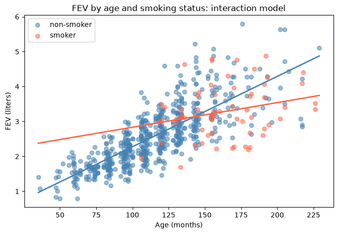

```python
plt.figure(figsize=(8, 5))
for status in ["non-smoker", "smoker"]:
    rows = df_fev[df_fev["Smoking status"] == status]
    smoker_value = int(status == "smoker")
    plt.scatter(rows["Age (months)"], rows["FEV"], alpha=0.55, color=colors[status], label=status)
    line_data = pd.DataFrame({"smoker": [smoker_value] * len(age_grid), "Age (months)": age_grid})
    line_data["smoker_x_age"] = line_data["smoker"] * line_data["Age (months)"]
    plt.plot(age_grid, fev_interaction_model.predict(line_data), color=colors[status], linewidth=2)

plt.xlabel("Age (months)")
plt.ylabel("FEV (liters)")
plt.title("FEV by age and smoking status: interaction model")
plt.legend()
plt.show()
```

9. Compare the models. Which do you think is “best”? Why? How could you investigate?